Skip to tutorial

Python tutorial and usage guide

# Single-cell potency, trajectory, and regulatory-activity analysis

DiffPy estimates differentiation potency, quantifies signaling entropy, constructs potency-guided diffusion trajectories, and infers tissue-specific transcription-factor regulatory activity in epithelial cells from single-cell RNA-sequencing data. SCENT and its fast proxy CCAT quantify cell differentiation potency without requiring prior biological knowledge, whereas SCIRA infers regulatory activity from TF–regulon networks and target-gene expression patterns.

## 1. Overview

The package analyzes normalized single-cell RNA-sequencing expression matrices with genes in rows and cells in columns. Dense NumPy arrays, pandas DataFrames, and SciPy sparse matrices are supported.

Choose an analysis path below. Signaling entropy and CCAT estimate cell potency; SCIRA estimates transcription-factor activity.

### Signaling entropy

Inputs**Expression + PPI network**Normalized gene-by-cell expression and a labeled PPI network

→

Preparation**Network integration**Apply log2(x + 1.1), align genes, and retain the largest connected network component

→

Calculation**Signaling entropy**Estimate cell potency from expression-weighted network transitions

### CCAT potency

Inputs**Expression + PPI network**Normalized gene-by-cell expression and a labeled PPI network

→

Calculation**CCAT**Estimate cell potency from expression-connectivity correlation

### Potency downstream

Input**Entropy or CCAT scores**Use potency estimates produced by either calculation above

→

Optional analyses**States and trajectory**Infer potency states; use potency scores with expression to infer diffusion coordinates and a root-cell group

### Regulatory activity

Inputs**Expression + tissue**Normalized gene-by-cell expression and one of nine supported tissue names

→

Calculation**SCIRA**Estimate transcription-factor activity in each cell

## 2. Installation

Python examples below include their captured text output and embedded figures. Shell commands are setup instructions; installation and extraction logs depend on your environment.

Python 3.10 or newer is required. Install from the package source directory or a built distribution:

```bash
python -m pip install .
```

Install the optional tools needed to regenerate the documentation figures with:

```bash
python -m pip install ".[docs]"
```

Chu, liver, and stomach are distributed separately in `DiffPy_test_data.zip`. Extract the archive and configure its parent directory before running the cohort examples:

```bash
mkdir -p diffpy-data
unzip DiffPy_test_data.zip -d diffpy-data
export DIFFPY_DATA_DIR="$PWD/diffpy-data"
```

The environment variable may contain multiple directories separated by the platform path separator. The PPI networks and all nine tissue regulons remain bundled inside DiffPy. As an alternative to the environment variable, pass `data_dir="/path/to/diffpy-data"` to `load_dataset()`.

## 3. Datasets

```
from diffpy import (
    available_datasets,
    load_dataset,
    load_ppi,
    load_regulon,
)

print(available_datasets())
chu = load_dataset("chu")
network = load_ppi("ppi_PC_2016")  # Used for all PPI-based results below
stomach_regulon = load_regulon("stomach")

print(chu["expression"].shape)
print(network.shape)
print(stomach_regulon.shape)
```

Output

```
('chu', 'liver', 'stomach', 'ppi_PC_2012', 'ppi_PC_2016', 'ppi_PC_2024', 'ppi_string_2020', 'TF-regulon_network_breast', 'TF-regulon_network_colon', 'TF-regulon_network_esophagus', 'TF-regulon_network_stomach', 'TF-regulon_network_kidney', 'TF-regulon_network_liver', 'TF-regulon_network_lung', 'TF-regulon_network_pancreas', 'TF-regulon_network_skin')
(18935, 479)
(11751, 11751)
(18165, 32)
```

| Resource | Main contents | Use |
| --- | --- | --- |
| `chu` | External test data: expression, phenotype, signaling entropy | Potency and state examples |
| `liver` | External test data: expression, stage codes | Diffusion trajectory example |
| `stomach` | External test data: expression, differentiation state | Regulatory-activity example |
| `ppi_PC_2012`, `ppi_PC_2016`, `ppi_PC_2024`, `ppi_string_2020` | Four bundled PPI networks (Pathway Commons and STRING) | Network-based potency |
| `TF-regulon_network_{tissue}` | Nine bundled signed TF regulon matrices | Regulatory-activity estimation |

The four bundled PPI networks use the canonical names `ppi_PC_2012`, `ppi_PC_2016`, `ppi_PC_2024`, and `ppi_string_2020`. Pass a canonical name to `load_ppi()`. The year shortcuts `"2012"`, `"2016"`, `"2024"`, and `"2020"` are also supported.

`load_dataset()` returns an ordinary dictionary. Access expression matrices and annotations by key, for example `chu["expression"]` and `chu["phenotype"]`. Annotation vectors correspond to expression columns by position. Their pandas Series indices are not guaranteed to contain expression cell identifiers, so align them by order rather than joining them by index.

### 3.1 Expression preprocessing

The external test-data expression cohorts have different preprocessing histories. Do not apply another log transformation to the liver or stomach matrices.

Network integration and signaling entropy require nonnegative, library-size-normalized, unlogged expression. `DoIntegPPI()` always applies `log2(x + 1.1)`; sparse input becomes dense because `log2(1.1)` is nonzero. An input maximum below 100 triggers a `RuntimeWarning` that the matrix may already be logged. CCAT and regulatory-activity estimation instead apply the sparse-safe transformation `log2(x + 1)` only when the input maximum exceeds 100, and emit a `RuntimeWarning` when they apply it.

| Dataset | Library-size normalized | Log-transformed | Transformation |
| --- | --- | --- | --- |
| Chu | Yes | No | None in the stored matrix; transformed by the analysis function |
| Liver | Yes | Yes | `log2(x + 1.1)` |
| Stomach | Yes, scale factor 10,000 | Yes | `log2(x + 1)` |

## 4. Network integration and signaling entropy

DoIntegPPI(expression, network, *, min_overlap=5000) CompSRana(integrated, *, include_normalized_local=False, n_jobs=1)

```
from diffpy import (
    CompSRana,
    DoIntegPPI,
    load_dataset,
    load_ppi,
)

chu = load_dataset("chu")
integrated = DoIntegPPI(
    chu["expression"],
    load_ppi("ppi_PC_2016"),
)
entropy = CompSRana(integrated, n_jobs=4)

print(entropy.signaling_entropy.head())
print(entropy.maximum_entropy)
```

Output

```
H1_Exp1.001    0.956958
H1_Exp1.002    0.956636
H1_Exp1.003    0.955336
H1_Exp1.004    0.955075
H1_Exp1.006    0.956174
Name: signaling_entropy, dtype: float64
6.98160844172042
```

The integration step validates that expression is nonnegative, applies `log2(x + 1.1)`, matches gene identifiers, checks overlap, and retains the largest connected network component. Supply library-size-normalized expression before log transformation. For each cell, signaling entropy builds expression-weighted transitions, calculates local Shannon entropy, and averages it using the stationary distribution.

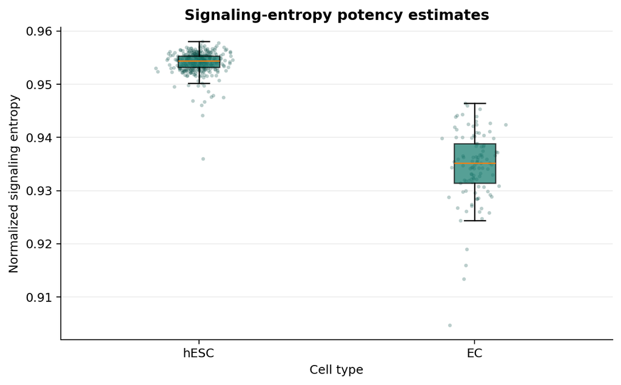

**Calculated result.** Median signaling entropy is 0.9544 in 374 hESCs and 0.9351 in 105 endothelial progenitor cells.

### Returned result

- `signaling_entropy`: one normalized entropy score per cell.
- `stationary_distribution`: gene-by-cell stationary probabilities.
- `local_entropy`: gene-by-cell local transition entropy.
- `normalized_local_entropy`: optional locally normalized entropy.
- `maximum_entropy`: network normalization constant.

## 5. Fast potency estimation with CCAT

CompCCAT(expression, network, *, min_overlap=5000)

```
from diffpy import CompCCAT, load_dataset, load_ppi

chu = load_dataset("chu")
ccat = CompCCAT(chu["expression"], load_ppi("ppi_PC_2016"))

print(ccat.describe())
```

Output

```
RuntimeWarning: Applying automatic log2(x + 1) transformation to expression values.
count    479.000000
mean       0.411074
std        0.048348
min        0.238722
25%        0.411354
50%        0.432556
75%        0.441516
max        0.466446
Name: ccat, dtype: float64
```

CCAT calculates one Pearson correlation per cell between gene expression and PPI network degree. Higher values indicate stronger expression of highly connected genes.

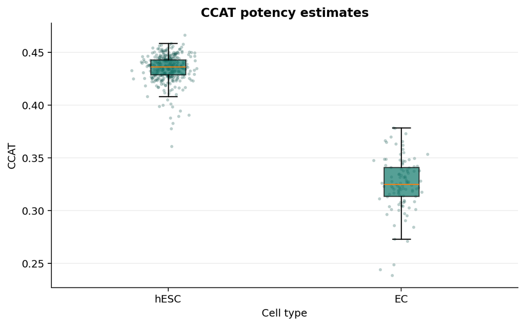

**Calculated result.** Median CCAT is 0.4364 in hESCs and 0.3253 in endothelial progenitor cells.

## 6. Discrete potency states

InferPotencyStates(potency, *, score_type="signaling_entropy", phenotype=None, variable_variance=True, max_states=5, random_state=0)

```
from diffpy import InferPotencyStates

states = InferPotencyStates(
    ccat,
    score_type="ccat",
    phenotype=chu["phenotype"],
    random_state=0,
)

print(states.states.value_counts().sort_index())
print(states.distribution)
print(states.heterogeneity)
```

Output

```
potency_state
1    363
2    116
Name: count, dtype: int64
potency_state    1    2
phenotype
EC               0  105
hESC           363   11
phenotype
EC     -0.000000
hESC    0.191433
Name: heterogeneity, dtype: float64
```

After estimating potency, InferPotencyStates() can determine whether cells separate into distinct potency states, which fits a mixture of Gaussians to logit-transformed SR values, or Z-transformed CCAT values. The inferred states are ordered from greatest to lowest potency, so state 1 always represents the greatest-potency group.

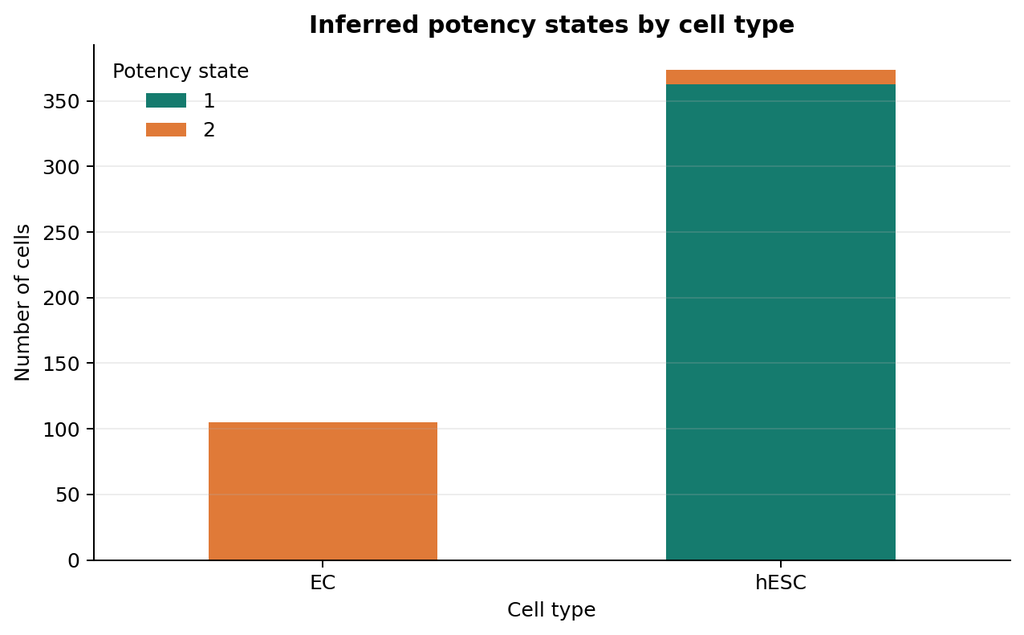

**Calculated result.** Potency-state assignments (state 1 is highest potency): EC: state 1 = 0, state 2 = 105; hESC: state 1 = 363, state 2 = 11.

## 7. Diffusion trajectory and root-cell inference

InferDMAPandRoot(potency, expression, *, mean_threshold=1.0, sd_threshold=0.25, k_neighbors=30, top_fraction=0.05, n_components=10) compute_diffusion_pseudotime(trajectory, *, root=None, paths_to=(1, 2, 3), window_width=0.1)

```
from diffpy import (
    CompCCAT,
    compute_diffusion_pseudotime,
    InferDMAPandRoot,
)
from diffpy import load_dataset, load_ppi

liver = load_dataset("liver")
potency = CompCCAT(liver["expression"], load_ppi("ppi_PC_2016"))

import matplotlib.pyplot as plt
import numpy as np
import pandas as pd

# Stage labels are stored in the annotation index, in expression-column order.
stages = pd.Series(liver["stage_codes"].index, index=potency.index)
stage_order = ["E10", "E11", "E12", "E13", "E14", "E15", "E17"]
colors = liver["plot_colors"].to_numpy()
values = [potency.to_numpy()[stages.to_numpy() == stage] for stage in stage_order]

fig, ax = plt.subplots(figsize=(7.2, 4.5))
boxes = ax.boxplot(values, patch_artist=True, showfliers=False)
ax.set_xticks(range(1, len(stage_order) + 1), stage_order)
for box, color in zip(boxes["boxes"], colors):
    box.set_facecolor(color)
    box.set_alpha(0.72)

rng = np.random.default_rng(260721)
for position, observations in enumerate(values, start=1):
    ax.scatter(
        rng.normal(position, 0.045, size=len(observations)), observations,
        s=9, alpha=0.28, color="#0d5149", linewidths=0,
    )
ax.set(
    title="Liver CCAT potency across embryonic stages",
    xlabel="Embryonic stage", ylabel="CCAT",
)
ax.grid(axis="y", alpha=0.22)
fig.tight_layout()
plt.show()

stage_summary = pd.DataFrame({"stage": stages, "CCAT": potency})
print(stage_summary.groupby("stage")["CCAT"].agg(["count", "median", "mean"]).reindex(stage_order).round(4))
```

Output

```
       count  median    mean
stage
E10       54  0.4542  0.4531
E11       70  0.4321  0.4285
E12       41  0.4245  0.4203
E13       65  0.4109  0.4069
E14       70  0.3956  0.3952
E15       77  0.3873  0.3881
E17       70  0.3642  0.3706
```

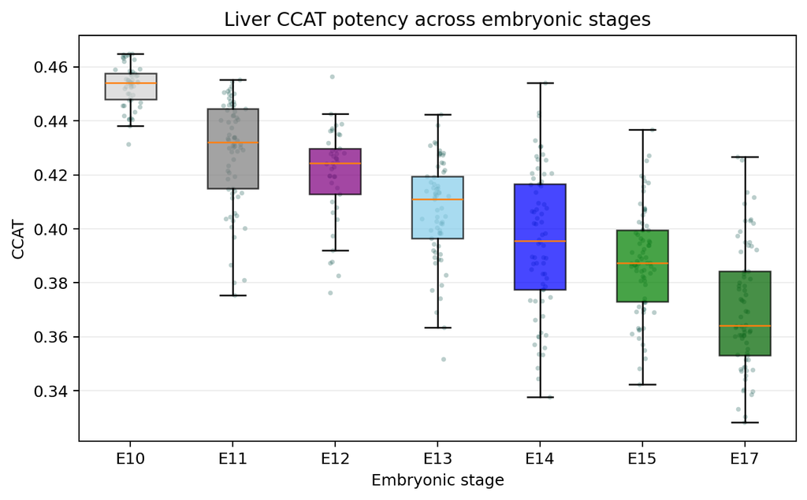

**Calculated result.** Median CCAT is 0.4542 at E10 and 0.3642 at E17.

Next, we want to see how we can use CCAT to inform the choice of a root state for inferring lineage trajectories. While we could simply pick the cell with the highest CCAT value as the root cell, we aim to make this choice more robust. This is achieved by the function `InferDMAPandRoot`. Briefly, the function selects genes from normalized, log-transformed expression and constructs a diffusion map and a symmetric diffusion operator across all cells. Subsequently, it applies weighted Walktrap clustering to the graph restricted to the highest-potency cells. The proportion of cells selected is determined by the `top_fraction` argument. Walktrap identifies communities within this graph, and the largest community is taken to represent the root state. The root cell is then identified as the cell within the root state with the smallest mean absolute distance from the cluster's median coordinates across the retained diffusion axes. We now run the function:

```
trajectory = InferDMAPandRoot(
    potency,
    liver["expression"],
    k_neighbors=30,
    top_fraction=0.05,
)
dpt = compute_diffusion_pseudotime(
    trajectory,
    paths_to=(1, 2, 3),
)

print("Root cell:", trajectory.root_cell)
print(trajectory.diffusion_coordinates.iloc[:, :2].head())
print(dpt.pseudotime.head())
```

Output

```
Root cell: E10.5D_1_03
                  DC1       DC2
E10.5D_1_01 -0.080230  0.013358
E10.5D_1_02 -0.060419  0.003480
E10.5D_1_03 -0.087027  0.014593
E10.5D_1_04 -0.093254  0.014808
E10.5D_1_05 -0.076543  0.009525
E10.5D_1_01    0.164428
E10.5D_1_02    0.559158
E10.5D_1_03    0.000000
E10.5D_1_04    0.133238
E10.5D_1_05    0.224770
Name: diffusion_pseudotime, dtype: float64
```

Color the same diffusion coordinates by embryonic stage:

```
coordinates = trajectory.diffusion_coordinates
figure, axis = plt.subplots(figsize=(7.2, 5.2))
for stage, color in zip(stage_order, colors, strict=True):
    selected = stages.to_numpy() == stage
    axis.scatter(
        coordinates.loc[selected, "DC1"],
        coordinates.loc[selected, "DC2"],
        s=22,
        alpha=0.78,
        color=color,
        label=stage,
        linewidths=0,
    )
root = coordinates.loc[trajectory.root_cell]
axis.scatter(root["DC1"], root["DC2"], marker="*", s=260, color="red", edgecolor="black", label="Root")
axis.set(title="Liver diffusion map colored by stage", xlabel="DC1", ylabel="DC2")
axis.legend(frameon=False, ncol=2)
figure.tight_layout()
plt.show()
```

Output

```
Figure output shown below.
```

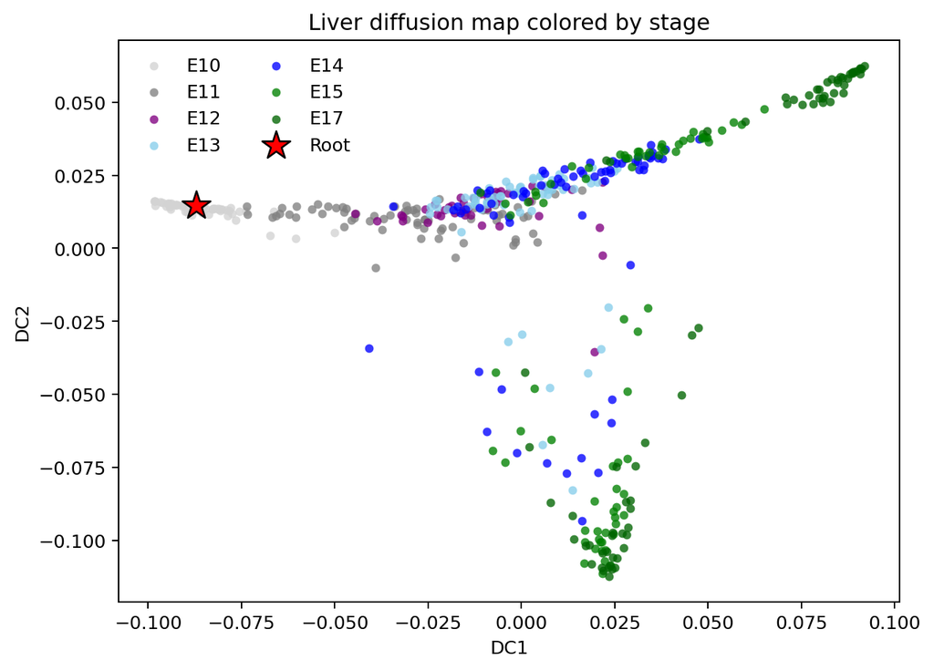

**Stage view.** The calculation inferred the E10 cell `E10.5D_1_03` as the root.

```
import matplotlib.pyplot as plt
from matplotlib.lines import Line2D

dc = trajectory.diffusion_coordinates
points = plt.scatter(
    dc["DC1"], dc["DC2"],
    c=potency.to_numpy(), cmap="viridis", s=20,
)
plt.scatter(
    dc.loc[trajectory.root_cell, "DC1"],
    dc.loc[trajectory.root_cell, "DC2"],
    marker="*", s=180, c="red", label="root",
)
plt.xlabel("Diffusion component 1")
plt.ylabel("Diffusion component 2")
ax = plt.gca()
root_legend = ax.legend()
ax.add_artist(root_legend)
potency_handles = [
    Line2D([], [], marker="o", linestyle="none", color=points.cmap(1.0),
           label="High potency"),
    Line2D([], [], marker="o", linestyle="none", color=points.cmap(0.0),
           label="Low potency"),
]
ax.legend(handles=potency_handles, loc="upper center", fontsize=8)
plt.tight_layout()
plt.show()
```

Output

```
Figure output shown below.
```

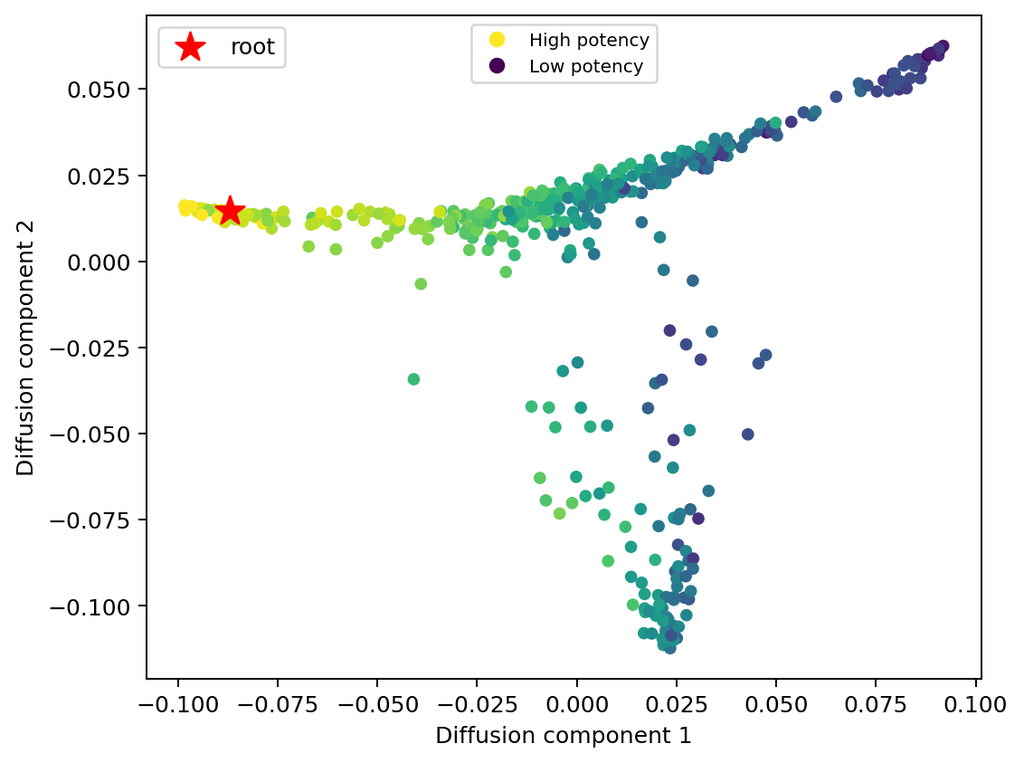

**Potency view.** The same diffusion coordinates are colored by calculated CCAT. The colored-dot legend indicates higher potency in yellow and lower potency in dark purple/blue.

Diffusion pseudotime (DPT) is estimated from the inferred root. The following plot shows the lineage trajectories. The requested one-based branch numbers in `paths_to` determine which smoothed diffusion-coordinate paths are returned.

```
figure, axis = plt.subplots(figsize=(7.2, 5.2))
points = axis.scatter(
    coordinates["DC1"],
    coordinates["DC2"],
    c=dpt.pseudotime.to_numpy(),
    cmap="viridis",
    s=22,
    alpha=0.82,
    linewidths=0,
)
for (branch, path), color in zip(
    dpt.paths.items(), ("darkgreen", "green", "yellow"), strict=True
):
    axis.plot(
        path["DC1"],
        path["DC2"],
        color=color,
        linewidth=3,
        label=f"Path to branch {branch}",
    )
tip_coordinates = coordinates.iloc[list(dpt.tip_indices)]
axis.scatter(
    tip_coordinates["DC1"],
    tip_coordinates["DC2"],
    marker="D",
    s=58,
    color="red",
    edgecolor="black",
    label="DPT tips",
)
axis.set(
    title="Liver diffusion pseudotime and lineage paths",
    xlabel="DC1",
    ylabel="DC2",
)
axis.legend(frameon=False)
figure.colorbar(points, ax=axis, label="Diffusion pseudotime")
figure.tight_layout()
plt.show()
```

Output

```
Figure output shown below.
```

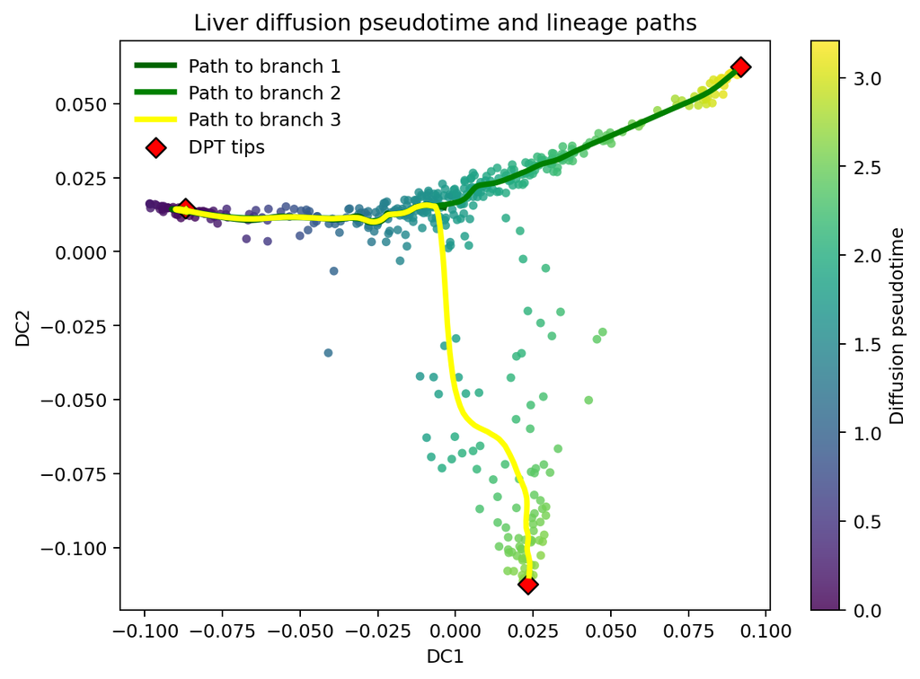

**DPT view.** Root: `E10.5D_1_03`. Pseudotime ranges from 0.0000 to 3.2071 (median 1.8237). The paths connect the root branch to the two differentiated branches.

## 8. Transcription-factor regulatory activity

SciraEstRegAct(expression, tissue, *, norm="z", n_jobs=1)

```
from diffpy import SciraEstRegAct, load_dataset

stomach = load_dataset("stomach")
activity = SciraEstRegAct(
    stomach["expression"],
    tissue="stomach",
    norm="z",
    n_jobs=4,
)

print(activity.shape)       # transcription factors x cells
print(activity.iloc[:5, :5].to_string())

# Average across transcription factors to obtain one value per cell.
average_tf_activity = activity.mean(axis=0)
print(average_tf_activity.head())
```

Output

```
(32, 400)
      AdultStomach_1.TCTACCAACCTACTGTGT-0  AdultStomach_1.TTAACTATCAACATCTCT-0  AdultStomach_1.TCGTAAGGGTTTGAGATC-0  AdultStomach_1.ACGAGCCATCCCTTGGAC-0  AdultStomach_1.CGCACCGGGTTTCCGACG-0
688                             -0.277579                            -0.159093                            -0.320094                            -0.259302                            -0.247038
1999                             0.328443                             0.838945                             0.801483                            -1.436862                             3.315440
2063                             0.744911                             2.040622                             1.199794                            -0.030842                            -0.725044
2101                             1.989298                             0.238388                             1.875442                            -0.308727                            -0.100550
2103                             1.642172                             0.982625                            -0.724120                             3.325975                            -0.796678
AdultStomach_1.TCTACCAACCTACTGTGT-0    0.407428
AdultStomach_1.TTAACTATCAACATCTCT-0    0.772494
AdultStomach_1.TCGTAAGGGTTTGAGATC-0    0.522839
AdultStomach_1.ACGAGCCATCCCTTGGAC-0    0.719848
AdultStomach_1.CGCACCGGGTTTCCGACG-0    0.504730
dtype: float64
```

The required `tissue` argument selects one of the packaged regulons for breast, colon, esophagus, kidney, liver, lung, pancreas, skin, or stomach; custom regulon input is not supported. Activity is the t-statistic of the regulon-predictor slope in a linear regression, not the expression level of the transcription factor itself. Because transcription factors are rows and cells are columns, `activity.mean(axis=0)` calculates average TF activity for each cell.

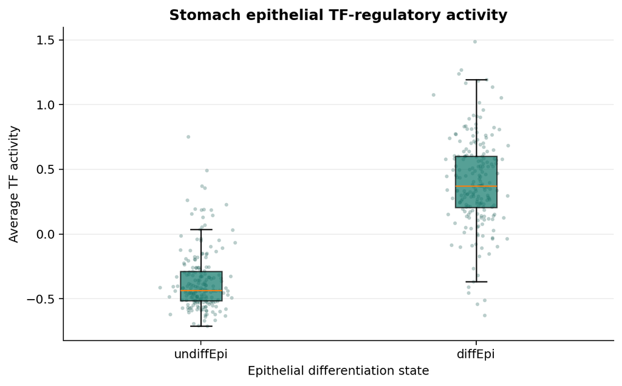

**Calculated result.** Across the 32 stomach-regulon transcription factors, median cell-level average activity is -0.4351 in 200 undifferentiated epithelial cells and 0.3704 in 200 differentiated epithelial cells.

## 9. API summary

| Function | Input | Output |
| --- | --- | --- |
| `DoIntegPPI` | Expression + PPI network | `IntegrationResult` |
| `CompSRana` | `IntegrationResult` | `SignalingEntropyResult` |
| `CompCCAT` | Expression + PPI network | Cell-indexed Series |
| `InferPotencyStates` | Potency scores + optional phenotype | `PotencyStateResult` |
| `InferDMAPandRoot` | Potency + expression | `TrajectoryResult` |
| `compute_diffusion_pseudotime` | `TrajectoryResult` | `DiffusionPseudotimeResult` |
| `SciraEstRegAct` | Expression + tissue | TF-by-cell DataFrame |

Every public function contains a detailed NumPy-style docstring. Inspect documentation directly in Python:

```
from diffpy import InferDMAPandRoot
help(InferDMAPandRoot)
```

Output

```
Help on function InferDMAPandRoot in module diffpy.InferDMAPandRoot:

InferDMAPandRoot(potency: 'Iterable[float] | pd.Series', expression: 'Any', *, expression_row_names: 'Iterable[Any] | None' = None, expression_col_names: 'Iterable[Any] | None' = None, mean_threshold: 'float' = 1.0, sd_threshold: 'float' = 0.25, k_neighbors: 'int' = 30, top_fraction: 'float' = 0.05, n_components: 'int' = 10) -> 'TrajectoryResult'
    Construct a diffusion map and infer a robust high-potency root cell.

    Parameters
    ----------
    potency
        One finite continuous potency score per expression column. A pandas
        Series is accepted, but cell order—not the Series index—is used for
        alignment.
    expression
        Normalized, log-transformed gene-by-cell expression matrix supplied as
        :class:`~diffpy.LabeledMatrix`, pandas DataFrame, NumPy array, or
        SciPy sparse matrix.
    expression_row_names
        Gene identifiers for an unlabeled expression array.
    expression_col_names
        Cell identifiers for an unlabeled expression array.
    mean_threshold
        Genes must have mean expression greater than this value.
    sd_threshold
        Genes must have sample standard deviation greater than this value.
    k_neighbors
        Nearest-neighbor count used to construct the adaptive diffusion kernel.
    top_fraction
        Fraction of highest-potency cells considered as root-state candidates.
        At least ten candidates are required.
    n_components
        Maximum number of nontrivial diffusion coordinates returned.

    Returns
    -------
    TrajectoryResult
        Diffusion coordinates, transition operator, root-state metadata,
        zero-based root index, root-cell name, and potency colors.

    Raises
    ------
    ValueError
        If dimensions do not align, potency contains nonfinite values, too few
        root candidates are selected, no genes pass filtering, or neighbor and
        component parameters are invalid.
    ImportError
        If ``python-igraph`` is unavailable for walk-trap community detection.

    Examples
    --------
    >>> from diffpy import CompCCAT, InferDMAPandRoot
    >>> from diffpy.datasets import load_dataset, load_ppi
    >>> liver = load_dataset("liver", data_dir="/path/to/diffpy-data")
    >>> potency = CompCCAT(liver["expression"], load_ppi("2012"))
    >>> result = InferDMAPandRoot(
    ...     potency, liver["expression"], k_neighbors=30, top_fraction=0.05
    ... )
    >>> result.root_cell in liver["expression"].col_names
    True

    Notes
    -----
    Walk-trap clustering is applied only to the highest-potency candidate
    subgraph. The largest community defines the candidate root state, and the
    selected root minimizes mean absolute distance from that state's
    component-wise median. Diffusion-axis signs are arbitrary; sign flips do
    not change geometry or biological interpretation. This implementation does
    not perform an implicit PCA step.
```

## 10. Reproducibility

### Recalculate every tutorial figure

The figures above are generated by `tools/generate_tutorial_plots.py`. The script calls the public package API for every biological calculation, saves the plots under `docs/images/`, and records the displayed numerical summaries in `docs/generated_results.json`. Matplotlib is used only for rendering. The generator also runs `tools/render_tutorial_outputs.py` to execute the displayed Python examples and refresh their text and plot outputs.

```bash
python -m pip install -e ".[docs]"
```

```bash
PYTHONPATH=src python tools/generate_tutorial_plots.py --n-jobs 4
```

The state-model seed is fixed at `random_state=0`, and plotting jitter uses seed `260721`. Diffusion axes can still reverse sign without changing the result's geometry.

## 11. License and scientific provenance

DiffPy is licensed under GPL-3.0-only. The implemented methods originate from the published SCENT and SCIRA research software and associated papers. See `NOTICE` and `LICENSE`, and cite the original method publications when using the package in scientific work.

## 12. References

1. Chu, Lifang, Ning Leng, Jue Zhang, et al. 2016. “Single-cell RNA-seq reveals novel regulators of human embryonic stem cell differentiation to definitive endoderm.” *Genome Biology* 17 (1): 173.
2. Han, Xiaoping, Ziming Zhou, Lijiang Fei, et al. 2020. “Construction of a Human Cell Landscape at Single-Cell Level.” *Nature* 581 (7781): 303–9.
3. Haghverdi, Laleh, Maren Büttner, F. Alexander Wolf, Florian Buettner, and Fabian J. Theis. 2016. “Diffusion pseudotime robustly reconstructs lineage branching.” *Nature Methods*. doi:10.1038/nmeth.3971.
4. Teschendorff, Andrew E., and Tariq Enver. 2017. “Single-cell entropy for accurate estimation of differentiation potency from a cell’s transcriptome.” *Nature Communications* 8 (1): 15599.
5. Teschendorff, Andrew E., Peter Sollich, and Reimer Kühn. 2014. “Signalling entropy: A novel network-theoretical framework for systems analysis and interpretation of functional omic data.” *Methods* 67 (3): 282–90.
6. Teschendorff, Andrew E., and Nannan Wang. 2020. “Improved Detection of Tumor Suppressor Events in Single-Cell RNA-Seq Data.” *NPJ Genomic Medicine* 5: 43.
7. Yang, Li, Wei-Hua Wang, Wei-Lin Qiu, Zhen Guo, Erfei Bi, and Cheng-Ran Xu. 2017. “A Single-Cell Transcriptomic Analysis Reveals Precise Pathways and Regulatory Mechanisms Underlying Hepatoblast Differentiation.” *Hepatology* 66 (5): 1387–401.